# Climate Change prediction

Eliott Van Dieren

2023-05-03

## Plotting the time series

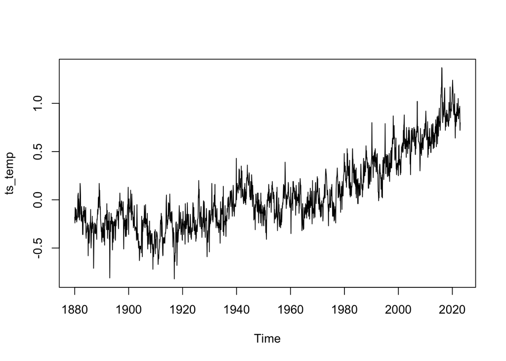

```r
temperature <- read.csv("Data/temperature.csv",skip = 1,row.names="Year")
temperature <- temperature[,1:12]

temp <- as.numeric(unlist(t(temperature)))
ts_temp <- ts(temp,start=1880,frequency=12)
plot(ts_temp)
```

```r
CO2_emissions <- read_csv("Data/CO2_emissions.csv")
```

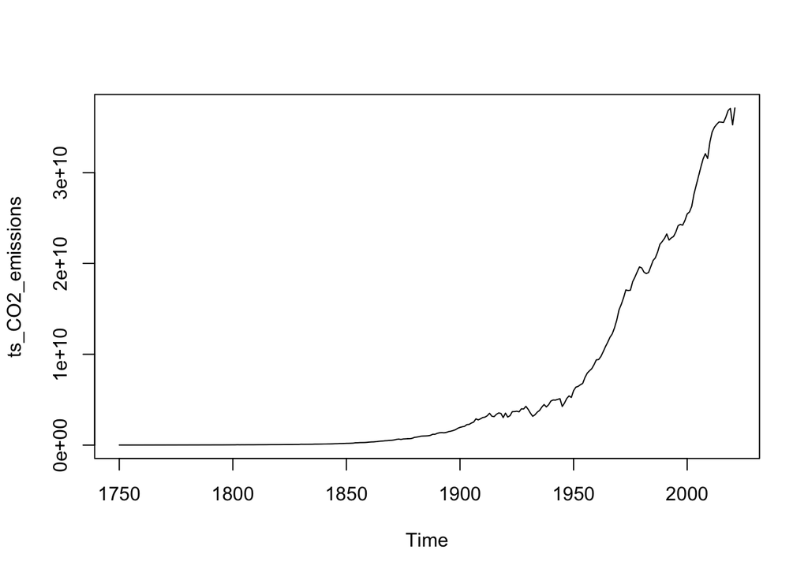

```r
CO2_emissions = CO2_emissions[CO2_emissions$Entity=="World",] # worldwide
ts_CO2_emissions <- ts(CO2_emissions$`Annual CO₂ emissions`,start=1750,frequency=1)
plot(ts_CO2_emissions)
```

```r
CO2_atmos <-  read_csv("Data/CO2_atmosphere.csv",skip=55)
```

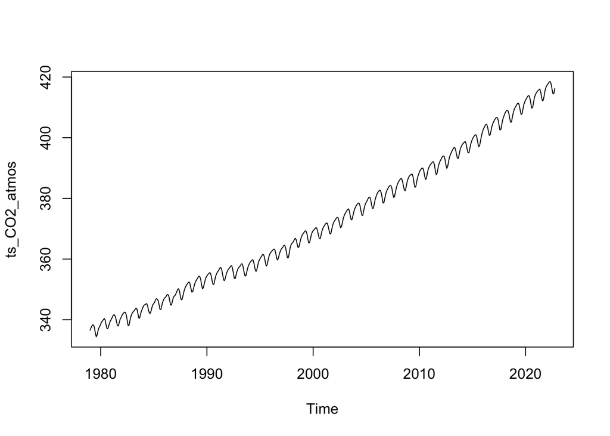

```r
ts_CO2_atmos = ts(CO2_atmos$average,start=1979,frequency=12)
plot(ts_CO2_atmos)
```

```r
# prove or refute the exponential trend : model linear + poly + exp and check params significance



# IF we want to be exact, we should look for the dependancy by diff twice, then get p and q from there. Then, we do the gls thing



# Utiliser stl() pour voir la décomp et voir la trend
```

## Truncating the temperature series

As one can see thanks to the plot above, we can identify a changing point of the trend in the 60s, which fluctuates between 1880 and 1960 then increases linearly from 1960 onwards. A reasonable assumption would therefore be that this linear trend would continue for the near future, as it did for around 60 years.

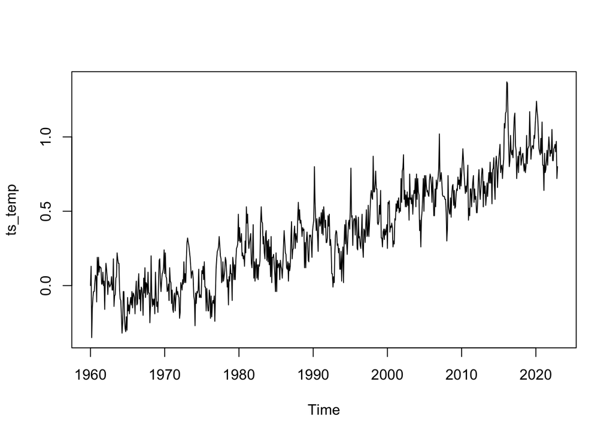

```r
start_y <- 1960
ts_temp <- window(ts_temp,start=start_y)
plot(ts_temp)
```

## Building a SARIMA model for the temperature series

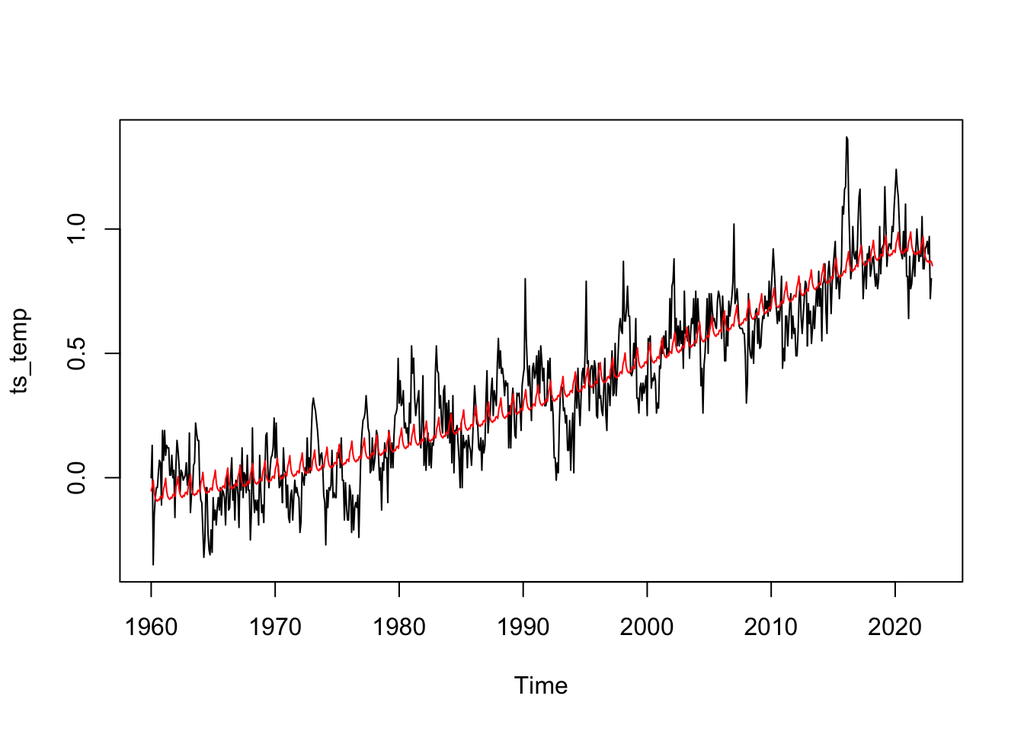

```r
# Trying to remove the upward trend, no seasonality seem to appear
# If we still observe seasonality, then s=12 might be the best choice
# (due to north hemisphere measurements?)

# Using the diff(1) so no seasonal diff but purely to make it stationary
#sd_temp <- diff(ts_temp, lag=1)
#plot(sd_temp,type="l")
# it is reasonable to see it as stationary, no trend or difference of the mean over time and the variance seem more or less constant

lmData <- data.frame(y = ts_temp,
                     month = as.factor(rep(1:12,length(ts_temp)/12)),
                     t = 1:length(ts_temp))


lmfit <- lm(y~ t + I(t^2) + exp(t/20) + month, data=lmData)
plot(ts_temp)
points(seq(start_y, 2023, length=length(ts_temp)),fitted(lmfit), type="l", col="red")
```

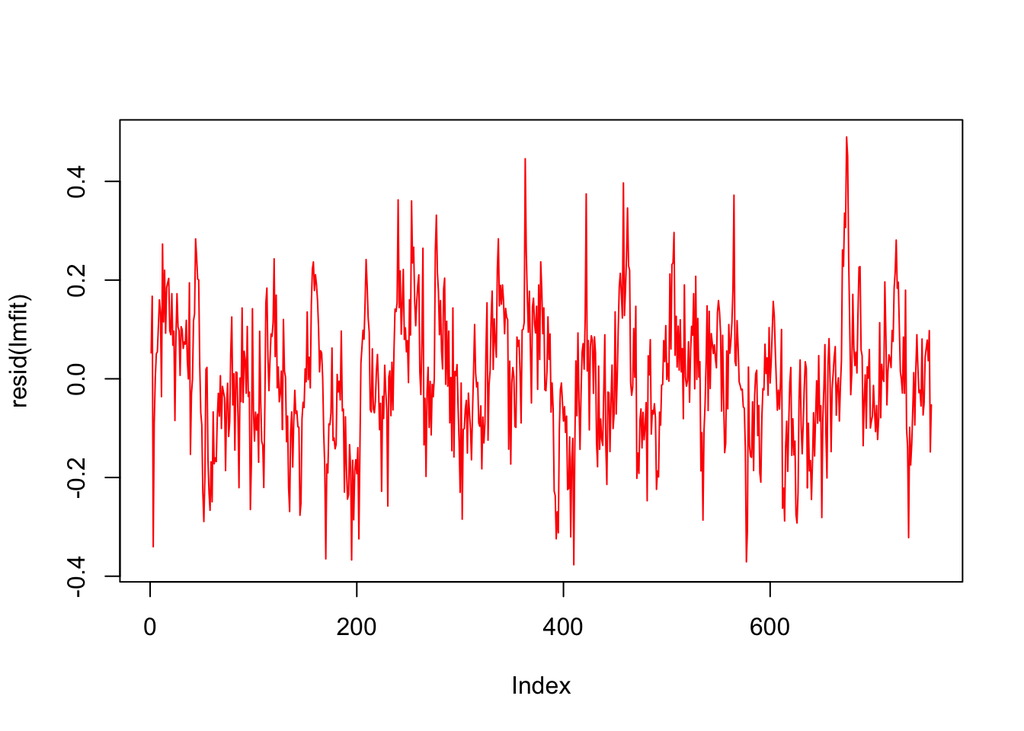

```r
plot(resid(lmfit), type="l", col="red")
```

```r
summary(lmfit)
```

```
##
## Call:
## lm(formula = y ~ t + I(t^2) + exp(t/20) + month, data = lmData)
##
## Residuals:
##      Min       1Q   Median       3Q      Max
## -0.37680 -0.08600 -0.00148  0.09103  0.48993
##
## Coefficients:
##               Estimate Std. Error t value Pr(>|t|)
## (Intercept) -5.307e-02  2.267e-02  -2.341  0.01948 *
## t            5.878e-04  9.996e-05   5.880  6.2e-09 ***
## I(t^2)       1.156e-06  1.350e-07   8.562  < 2e-16 ***
## exp(t/20)   -6.206e-18  2.086e-18  -2.974  0.00303 **
## month2       1.459e-02  2.460e-02   0.593  0.55326
## month3       4.157e-02  2.460e-02   1.690  0.09147 .
## month4      -1.145e-02  2.460e-02  -0.465  0.64179
## month5      -3.192e-02  2.460e-02  -1.297  0.19487
## month6      -4.127e-02  2.460e-02  -1.678  0.09386 .
## month7      -4.585e-02  2.460e-02  -1.864  0.06276 .
## month8      -3.851e-02  2.460e-02  -1.565  0.11790
## month9      -4.228e-02  2.460e-02  -1.719  0.08612 .
## month10     -2.842e-02  2.460e-02  -1.155  0.24843
## month11     -2.741e-02  2.461e-02  -1.114  0.26574
## month12     -3.717e-02  2.461e-02  -1.511  0.13132
## ---
## Signif. codes:  0 '***' 0.001 '**' 0.01 '*' 0.05 '.' 0.1 ' ' 1
##
## Residual standard error: 0.1381 on 741 degrees of freedom
## Multiple R-squared:  0.8423, Adjusted R-squared:  0.8393
## F-statistic: 282.7 on 14 and 741 DF,  p-value: < 2.2e-16
```

# Using GAMs and SARIMA model for residual (Prediction only)

Instead of working with Generalized Least Square, one can first try to fit the trend with a Generalized Additive model and then find SARIMA parameters for its residuals.

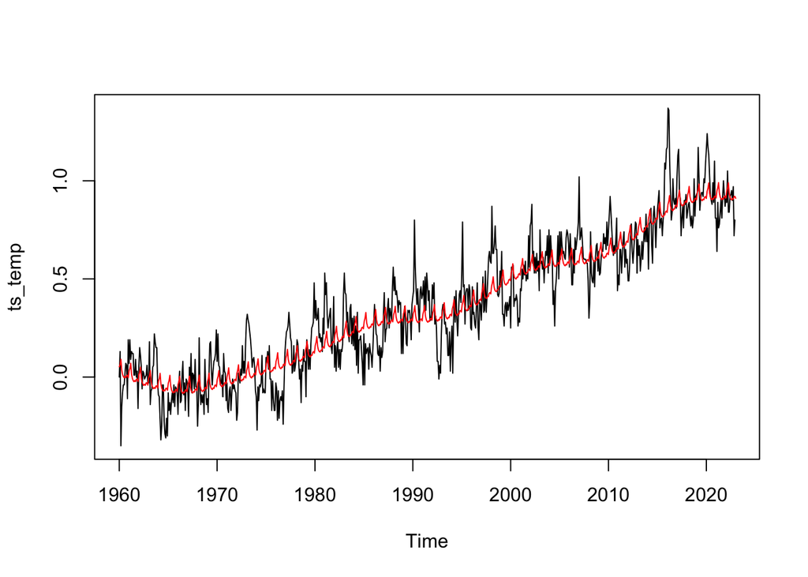

```r
gamfit <- gam(y~s(t)+month, data=lmData)
plot(ts_temp)
points(seq(start_y, 2023, length=length(ts_temp)), fitted(gamfit), type="l", col="red")
```

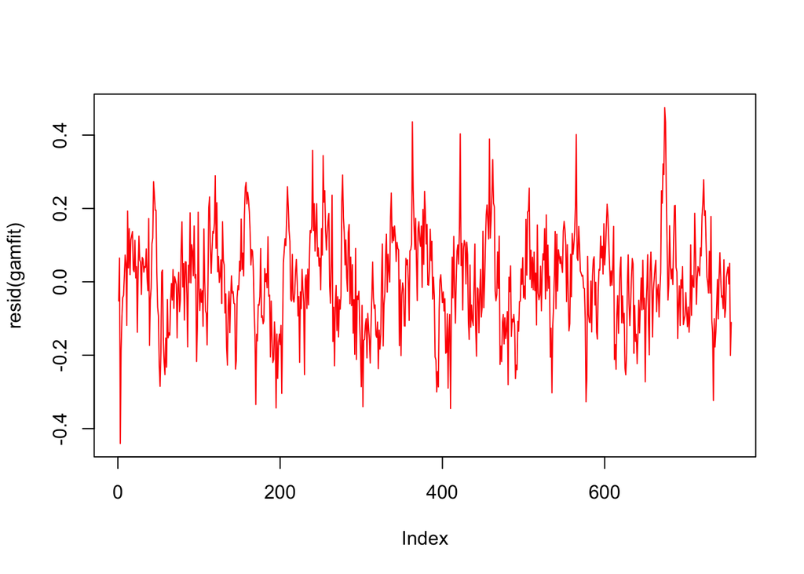

```r
plot(resid(gamfit), type="l", col="red")
```

```r
summary(gamfit)
```

```
##
## Family: gaussian
## Link function: identity
##
## Formula:
## y ~ s(t) + month
##
## Parametric coefficients:
##             Estimate Std. Error t value Pr(>|t|)
## (Intercept)  0.38522    0.01692  22.766   <2e-16 ***
## month2       0.01470    0.02393   0.614   0.5391
## month3       0.04178    0.02393   1.746   0.0812 .
## month4      -0.01114    0.02393  -0.466   0.6416
## month5      -0.03153    0.02393  -1.318   0.1880
## month6      -0.04080    0.02393  -1.705   0.0886 .
## month7      -0.04532    0.02393  -1.894   0.0586 .
## month8      -0.03793    0.02393  -1.585   0.1133
## month9      -0.04166    0.02393  -1.741   0.0821 .
## month10     -0.02777    0.02393  -1.160   0.2463
## month11     -0.02674    0.02393  -1.117   0.2643
## month12     -0.03650    0.02393  -1.525   0.1277
## ---
## Signif. codes:  0 '***' 0.001 '**' 0.01 '*' 0.05 '.' 0.1 ' ' 1
##
## Approximate significance of smooth terms:
##        edf Ref.df     F p-value
## s(t) 8.753  8.982 468.5  <2e-16 ***
## ---
## Signif. codes:  0 '***' 0.001 '**' 0.01 '*' 0.05 '.' 0.1 ' ' 1
##
## R-sq.(adj) =  0.848   Deviance explained = 85.2%
## GCV = 0.018541  Scale est. = 0.018032  n = 756
```

```r
# gam is better (can be seen in the plots that it averages it better)
```

As seen above, both models are pretty good regarding the trend approximation, and both residuals seem relatively stationary, with values ranging from -0.4 to 0.4, and with no apparent remaining trend. If we simply look at the sum of squared error, we see that the GAM model has a lower error than the linear model.

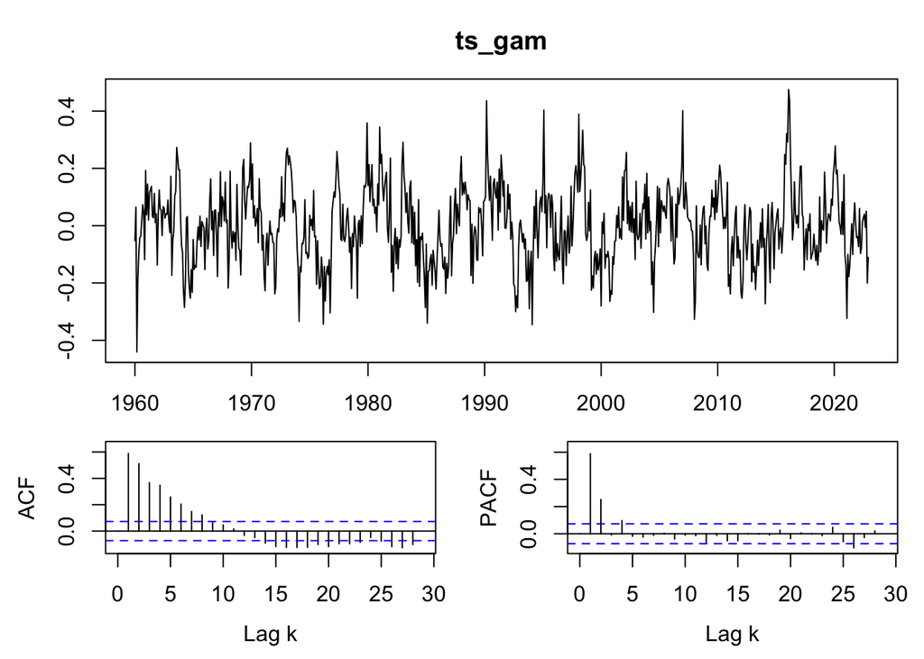

```r
ts_gam <- ts(resid(gamfit),start=start_y,frequency=12)
PlotACF(ts_gam)
```

```r
# 10log_10(n) = 28.78522
# s = 12, so we will check for k=1,2 and thats it
```

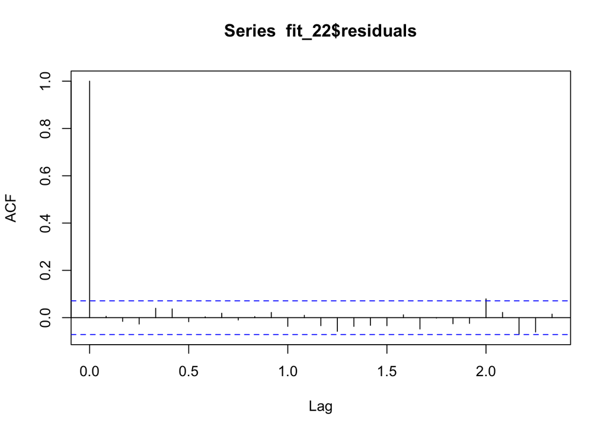

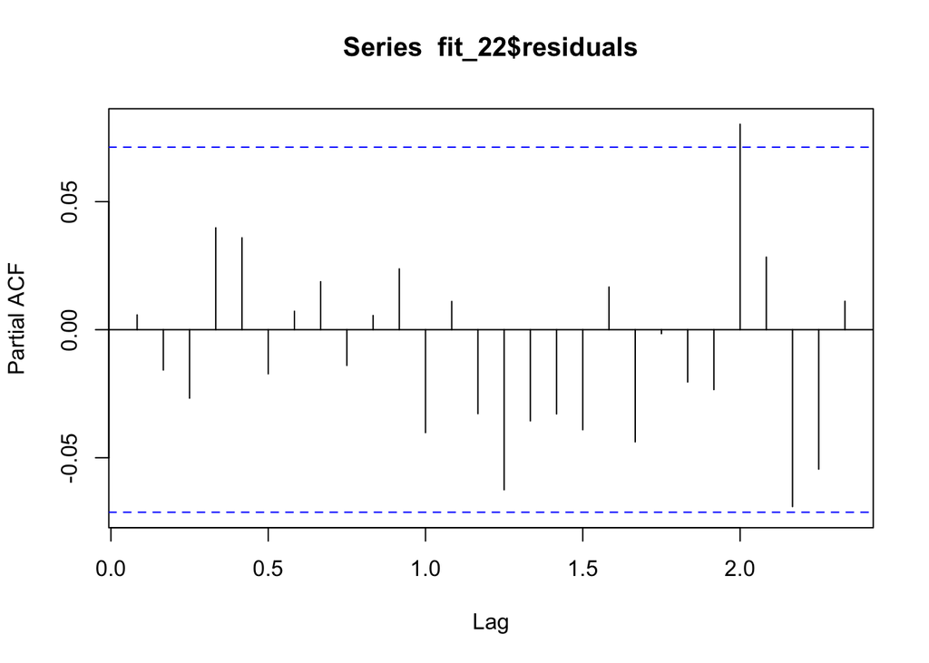

```r
fit_22 <- arima(ts_gam, order=c(2,0,2))
acf(fit_22$residuals); pacf(fit_22$residuals)
```

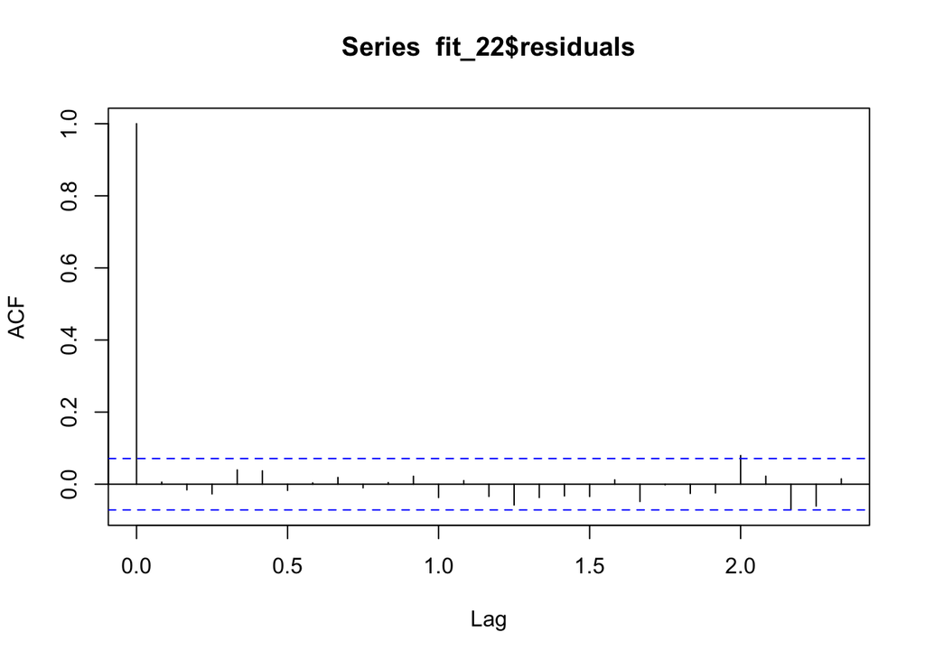

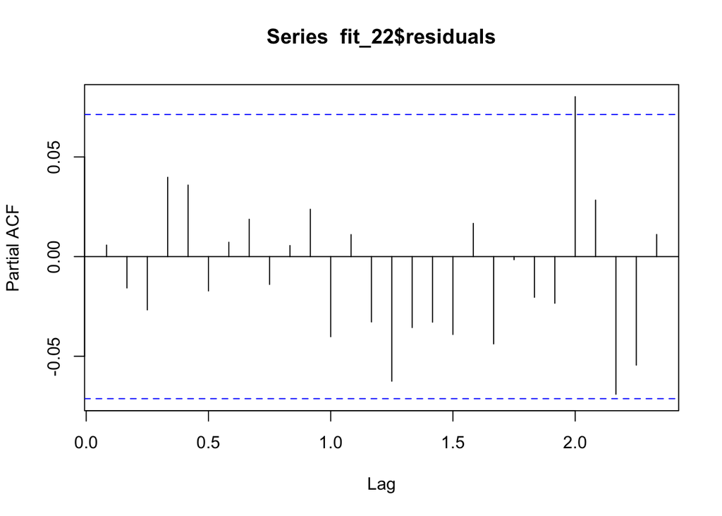

```r
# Diagnostics
acf(fit_22$residuals); pacf(fit_22$residuals)
```

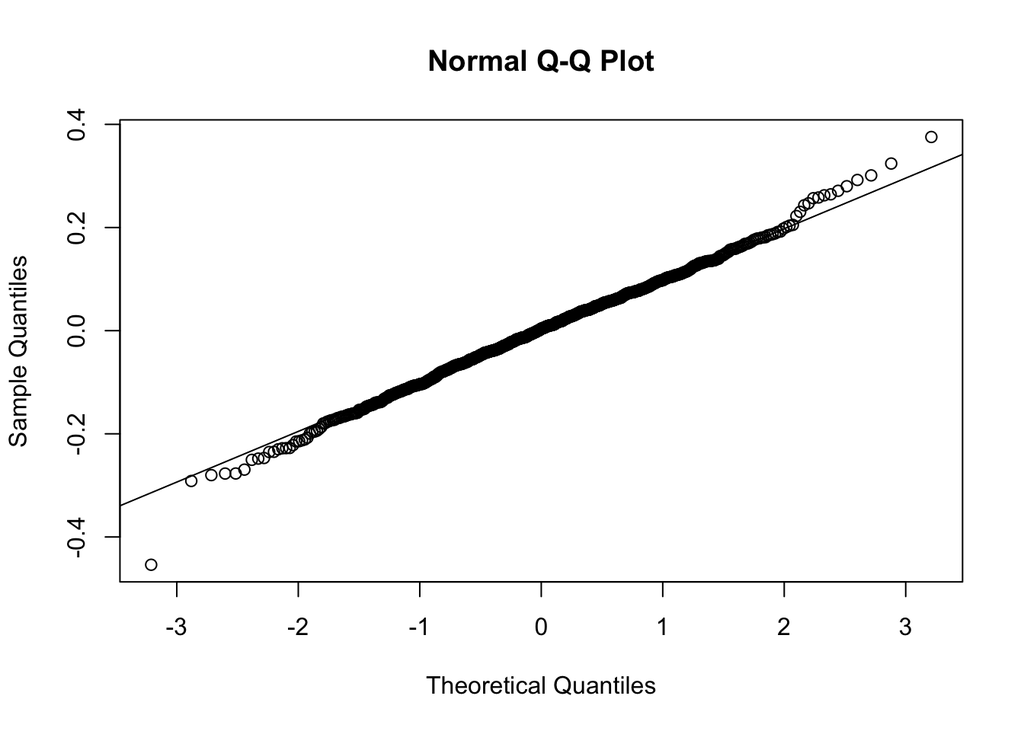

```r
qqnorm(fit_22$residuals)
qqline(fit_22$residuals)
```

QQPlots seem reasonable, PACF and ACF looks good for white noise.

Now one can have a look at submodels of the ARMA plot and check whether lower orders for the AR and MA component make sense

```r
# Checking from (2,0,2) to submodels

fit_21 <- arima(ts_gam, order=c(2,0,1))
fit_12 <- arima(ts_gam, order=c(1,0,2))
fit_11 <- arima(ts_gam, order=c(1,0,1))
fit_23 <- arima(ts_gam, order=c(2,0,3))
fit_24 <- arima(ts_gam, order=c(2,0,4))
cat(c(fit_22$aic,fit_21$aic,fit_12$aic, fit_11$aic,fit_23$aic,fit_24$aic))
```

```
## -1276.773 -1274.074 -1271.36 -1271.385 -1276.293 -1275.861
```

```r
#For model comparison, the model with the lowest AIC score is preferred. The absolute values of the AIC scores do not matter. These scores can be negative or positive.  -> fit_22 seem to be the best
# see screenshot for citation


n <- length(ts_gam)
train <- 1:(n-floor(n/3))
Err <- array(0,c(3, floor(n/3)-2+1 )) # rolling 2-step ahead forecast
for(j in 0:(floor(n/3)-2)){
  fit <- arima(ts_gam[train+j], order=c(2,0,3))
  Err[1,j+1] <- sum(ts_gam[c(1,2) + end(train)[1]+j] - predict(fit, n.ahead=2)$pred)^2
  fit <- arima(ts_gam[train+j], order=c(2,0,2))
  Err[2,j+1] <- sum(ts_gam[c(1,2) + end(train)[1]+j] - predict(fit, n.ahead=2)$pred)^2
  fit <- arima(ts_gam[train+j], order=c(1,0,2))
  Err[3,j+1] <- sum(ts_gam[c(1,2) + end(train)[1]+j] - predict(fit, n.ahead=2)$pred)^2
}
rowMeans(Err)
```

```
## [1] 0.03243841 0.03237781 0.03268235
```

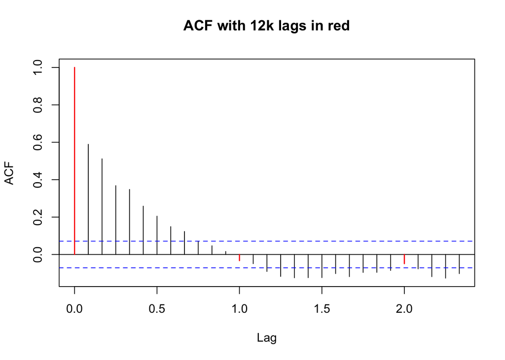

```r
# 0.03243841 0.03237781 0.03268235

# Both for AIC and rolling -> fit22 seem nice, it also has normal QQplots and residuals are white noise

# Next step : check for PQ (see slides) -> how it behaves to previous months (1 behind, two behind etc?) -> it is not taken into account yet
fit_22_ts <- resid(fit_22)


# On the ts_gam ts
myacf <- acf(ts_gam, main="ACF with 12k lags in red")
season_lags <- seq(0,10*log(length(ts_gam),10), by=12)
points(myacf$lag[1+season_lags], myacf$acf[1+season_lags], col="red", type="h", lwd=1.5)
```

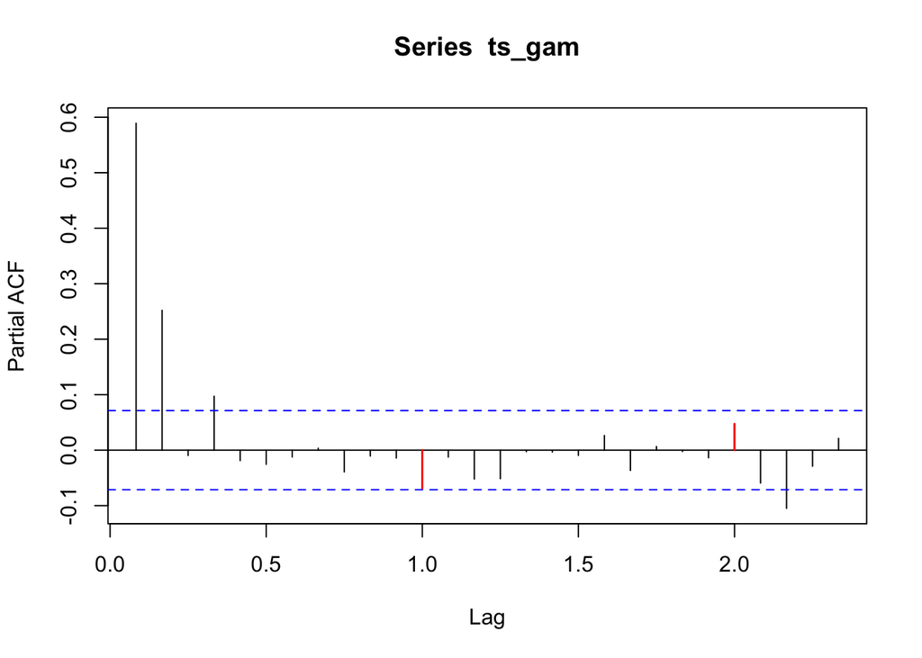

```r
mypacf <- pacf(ts_gam)
points(mypacf$lag[season_lags], mypacf$acf[season_lags], col="red", type="h", lwd=1.5)
```

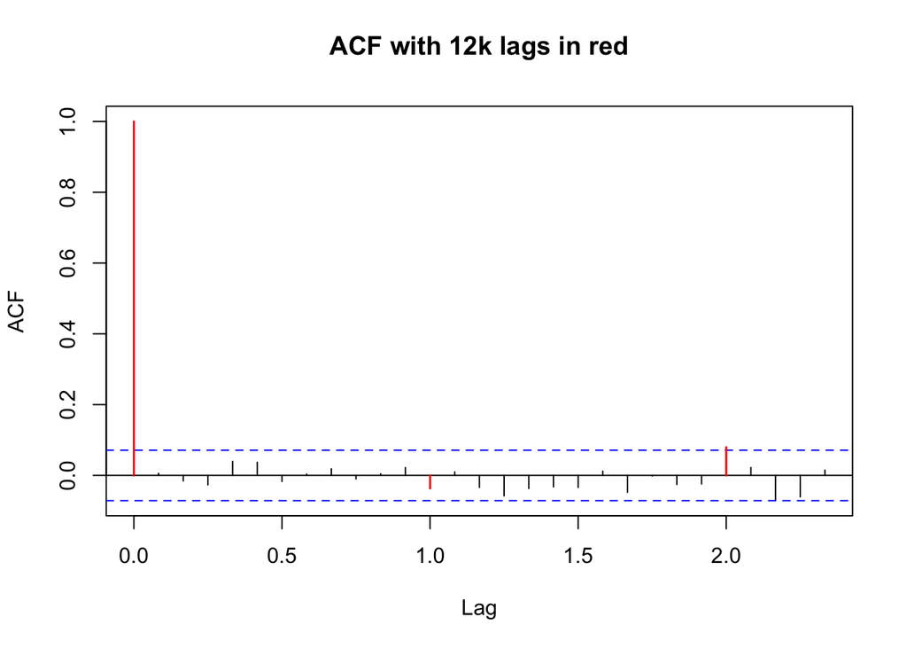

```r
# On the residuals of fit_22
myacf <- acf(fit_22_ts, main="ACF with 12k lags in red")
season_lags <- seq(0,10*log(length(fit_22_ts),10), by=12)
points(myacf$lag[1+season_lags], myacf$acf[1+season_lags], col="red", type="h", lwd=1.5)
```

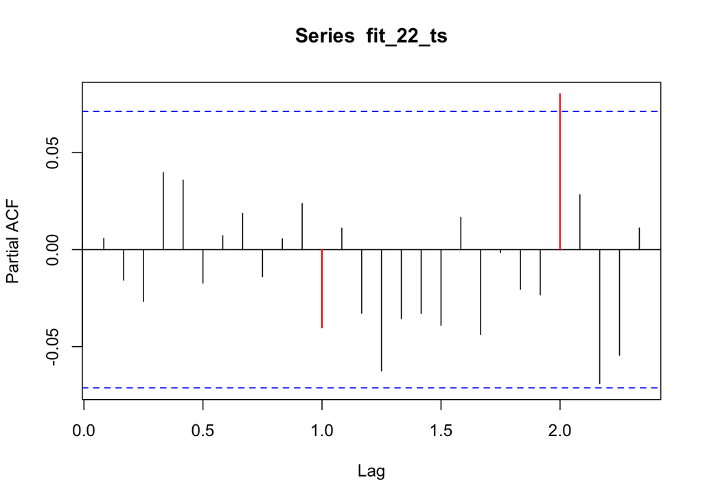

```r
mypacf <- pacf(fit_22_ts)
points(mypacf$lag[season_lags], mypacf$acf[season_lags], col="red", type="h", lwd=1.5)
```

```r
auto.arima(ts_gam)
```

```
## Series: ts_gam
## ARIMA(2,0,3)(1,0,0)[12] with zero mean
##
## Coefficients:
##          ar1     ar2     ma1      ma2      ma3     sar1
##       0.1874  0.5279  0.2604  -0.1751  -0.0731  -0.0404
## s.e.  0.2209  0.1669  0.2208   0.0924   0.0547   0.0372
##
## sigma^2 = 0.01068:  log likelihood = 645.73
## AIC=-1277.46   AICc=-1277.31   BIC=-1245.06
```

```r
final_fit <- arima(ts_gam,order=c(2,0,2),seasonal = c(2,0,0))
sub_final_fit <- arima(ts_gam,order=c(2,0,2),seasonal = c(1,0,0))

c(final_fit$aic,fit_22$aic,sub_final_fit$aic)
```

```
## [1] -1278.698 -1276.773 -1275.818
```

```r
n <- length(ts_gam)
train <- 1:(n-floor(n/3))
Err <- array(0,c(3, floor(n/3)-2+1 )) # rolling 2-month ahead forecast
for(j in 0:(floor(n/3)-2)){
  fit <- arima(ts_gam[train+j], order=c(2,0,2))
  Err[1,j+1] <- sum(ts_gam[c(1,2) + end(train)[1]+j] - predict(fit, n.ahead=2)$pred)^2
  fit <- arima(ts_gam[train+j],order=c(2,0,2),seasonal = c(2,0,0))
  Err[2,j+1] <- sum(ts_gam[c(1,2) + end(train)[1]+j] - predict(fit, n.ahead=2)$pred)^2
  fit <- arima(ts_gam[train+j],order=c(2,0,2),seasonal = c(1,0,0))
  Err[3,j+1] <- sum(ts_gam[c(1,2) + end(train)[1]+j] - predict(fit, n.ahead=2)$pred)^2
}
rowMeans(Err)
```

```
## [1] 0.03237781 0.03222906 0.03243106
```

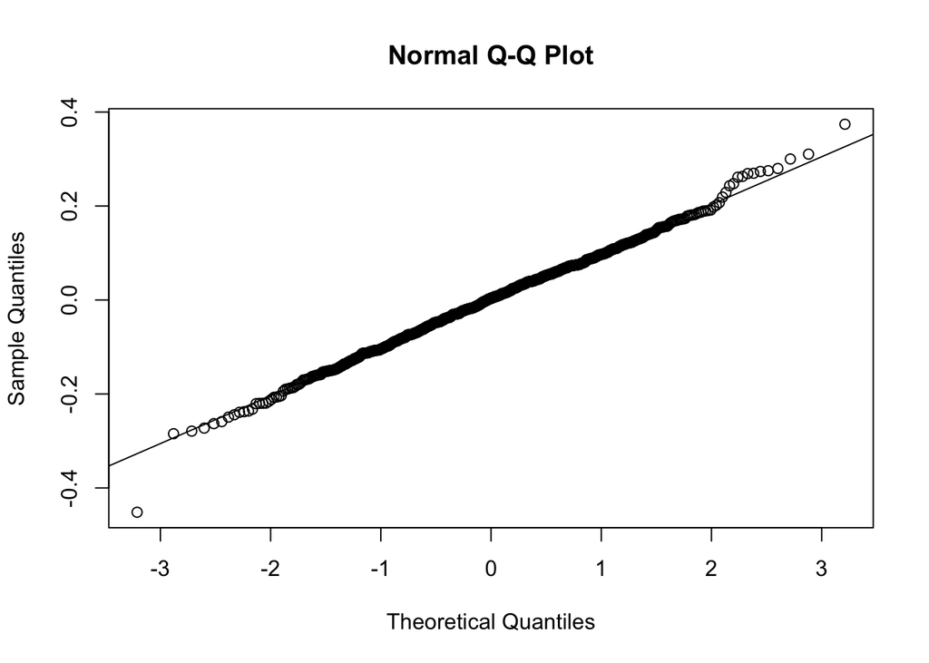

```r
# 0.03237781 0.03222906 0.03243106

# So, one sees that the final SARIMA(2,0,2)x(2,0,0) yields both lowest AIC and predictive residuals
resid_f_fit <- resid(final_fit)
qqnorm(resid_f_fit)
qqline(resid_f_fit)
```

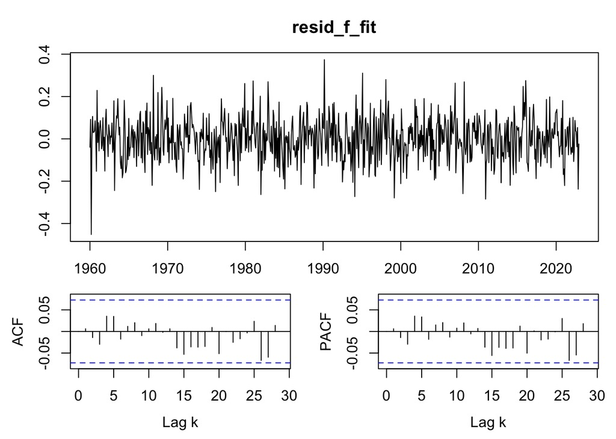

```r
PlotACF(resid_f_fit)
```

So the final model would be SARIMA (2,0,2)x(2,0,0). auto.arima would give us ARIMA(2,0,3)(1,0,0)[12] with zero mean, which is slightly different from what we have found. However, we get lower AIC (-1277.461 vs -1278.698) and lower residual error (0.03222906 vs 0.03252401)

```r
auto <- auto.arima(ts_gam)

c(auto$aic,final_fit$aic)
```

```
## [1] -1277.461 -1278.698
```

```r
n <- length(ts_gam)
train <- 1:(n-floor(n/3))
Err <- array(0,c(3, floor(n/3)-2+1 )) # rolling 2-step ahead forecast
for(j in 0:(floor(n/3)-2)){
  fit <- arima(ts_gam[train+j], order=c(2,0,2))
  Err[1,j+1] <- sum(ts_gam[c(1,2) + end(train)[1]+j] - predict(fit, n.ahead=2)$pred)^2
  fit <- arima(ts_gam[train+j],order=c(2,0,2),seasonal = c(2,0,0))
  Err[2,j+1] <- sum(ts_gam[c(1,2) + end(train)[1]+j] - predict(fit, n.ahead=2)$pred)^2
  fit <- arima(ts_gam[train+j],order=c(2,0,3),seasonal = c(1,0,0))
  Err[3,j+1] <- sum(ts_gam[c(1,2) + end(train)[1]+j] - predict(fit, n.ahead=2)$pred)^2
}
```

[output not shown]

[output cut: 25 more lines]

[output not shown]

```r
rowMeans(Err)
```

```
## [1] 0.03237781 0.03222906 0.03252401
```

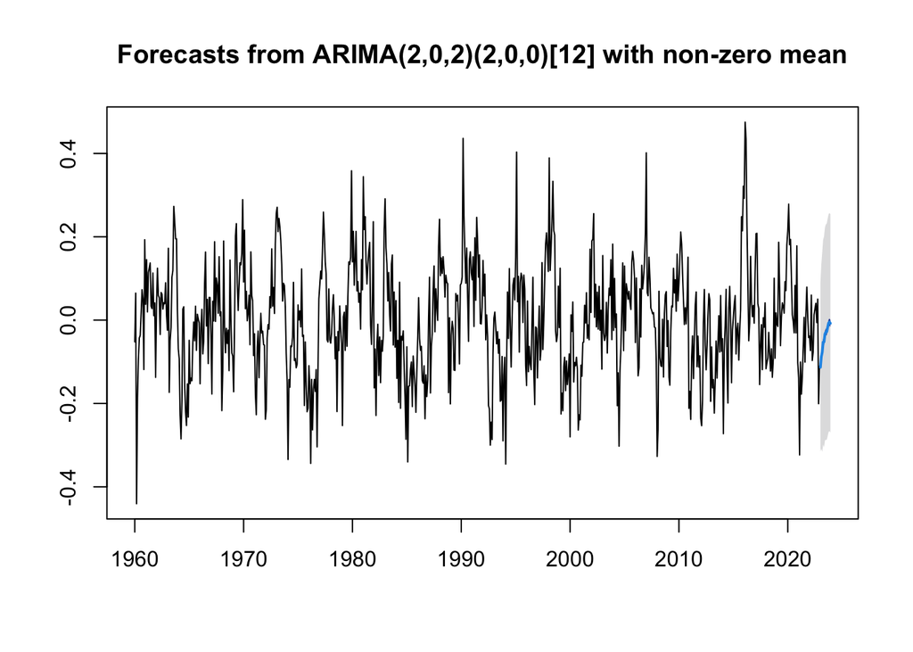

```r
fit <- Arima(ts_gam, order=c(2,0,2), seasonal=c(2,0,0)) # capital
preds <- forecast(fit, 12, c(0.05,0.95))
plot(preds)
```

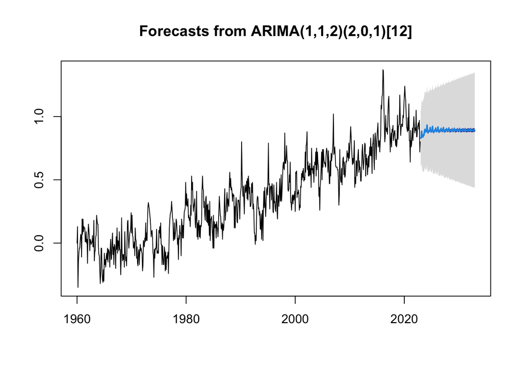

```r
# faire residu + trend

tot_auto <- auto.arima(ts_temp)
auto_preds <- forecast(tot_auto, 12*10, c(0.05,0.95))
plot(auto_preds)
```

## Todo list:

- Import the data, transform to `ts()` object then plot them
- Build a SARIMA model for (a part of) the temperature series (To wrap up : see slide 29)
  - Identify seasonality and trend from the plots and common sense (tip, si la variance increase, bonne idée de log la time series en elle même (faut faire gaffe car je pense que ça sera négatif donc rip.))
  - To remove the trend, one can fit various models to model the mean. Once this model is fitted, we extract its residuals which will be the difference between the time series and the fitted data (sqrd error?) -> >GAM works well for truncated time series
  - Find the seasonality parameter `s` (To remove seasonality, we can differentiate the data with respect to a given lag (on the residuals)) -> maybe not usefull given the previous points? -> it is 12 (see frequency)
  - Once this is done, we have a residuals (time series) from which we can build a SARIMA model on, and fit its order and parameters with ACF/PACF. ( library(DescTools)) slide 21-22 pour explication générale d’un ARMA si on veut parler un peu + du théorique. Quand on ajoute le S dans ARMA, on ajoute des polynômes de differentiabilité. all parameters are estimated by maximum likelihood using function arima() in R
  - To wrap up : see slide 29
- Perform residual diagnostics and predictive checking for the candidate models to select your final model. (c’est dans les slides -> on identifie un gros model SARIMA du point précédement, et on test ici toutes les combinaisons des ordres + petits pour submodels), predictive checking -> see slide.
- Visualize your predictions until 2050 using the final model.
- After Lecture 10 try to answer the two questions above (is there seasonality in the temperature time series, and what is the form of global warming). Now, what form does global warming take? +if you feel a bit lost, focus first on the simpler 1970-2005 period, where the trend can be modeled simply as linear in time